# Decision Tree

### Importing the libraries

```python
import numpy as np
import matplotlib.pyplot as plt
import pandas as pd
```

### Importing the dataset

```python
dataset = pd.read_csv('Social_Network_Ads.csv')
```

```python
dataset.head()
```

|  | Age | EstimatedSalary | Purchased |
| --- | --- | --- | --- |
| 0 | 19 | 19000 | 0 |
| 1 | 35 | 20000 | 0 |
| 2 | 26 | 43000 | 0 |
| 3 | 27 | 57000 | 0 |
| 4 | 19 | 76000 | 0 |

```python
X = dataset.iloc[:, :-1].values   # declaring feature matrix
y = dataset.iloc[:, -1].values    # declaring target varibale
```

```python
# y
```

### Splitting the dataset into the Training set and Test set

```python
from sklearn.model_selection import train_test_split

X_train, X_test, y_train, y_test = train_test_split(X, y, test_size = 0.25, random_state = 0)
```

```python
# print(X_train)
```

```python
print(len(y_train))
```

```
300
```

```python
print(len(X_test))
```

```
100
```

```python
print(len(y_test))
```

```
100
```

### Feature Scaling (Optional)

```python
# from sklearn.preprocessing import StandardScaler

# sc = StandardScaler()
# X_train = sc.fit_transform(X_train)
# X_test = sc.transform(X_test)
```

### Building the Decision Tree on the Training set

```python
from sklearn.tree import DecisionTreeClassifier

classifier = DecisionTreeClassifier(random_state = 0)
```

```python
#fitting decision tree on data

classifier = classifier.fit(X_train,y_train)
```

### Predicting the Test set results

```python
y_pred = classifier.predict(X_test)
```

```python
y_pred
```

```
array([0, 0, 0, 0, 0, 0, 0, 1, 0, 0, 0, 0, 0, 1, 0, 1, 1, 0, 1, 0, 0, 0,
       0, 1, 0, 1, 0, 0, 0, 0, 0, 0, 1, 0, 0, 0, 0, 0, 0, 1, 0, 0, 0, 0,
       1, 0, 0, 0, 0, 1, 1, 0, 0, 1, 1, 1, 0, 0, 1, 0, 0, 1, 0, 1, 0, 1,
       0, 0, 0, 1, 1, 0, 0, 1, 0, 0, 0, 0, 1, 1, 1, 1, 0, 0, 1, 0, 0, 1,
       1, 0, 0, 1, 0, 0, 0, 1, 0, 1, 1, 1])
```

```python
# print(np.concatenate((y_pred.reshape(len(y_pred),1), y_test.reshape(len(y_test),1)),1))
```

### Making the Confusion Matrix

**NOTE:**

- A confusion matrix can be used to visualize true and false positives and negatives. The rows of the matrix are the true classes of the instances, and the columns are the predicted classes of the instances.
- When creating a confusion matrix it is important to understand and maintain a convention for which differentiating positive and negative label values. The usual convention is to call the $1$ case positive and the $0$ case negative.

```python
from sklearn.metrics import confusion_matrix

cm = confusion_matrix(y_test, y_pred)
print(cm)
```

```
[[62  6]
 [ 4 28]]
```

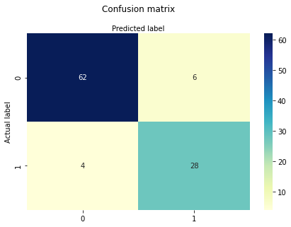

```python
import matplotlib.pyplot as plt
import seaborn as sns

class_names=[0,1] # name  of classes

fig, ax = plt.subplots()
tick_marks = np.arange(len(class_names))
plt.xticks(tick_marks, class_names)
plt.yticks(tick_marks, class_names)

# create heatmap
sns.heatmap(pd.DataFrame(cm), annot=True, cmap="YlGnBu" ,fmt='g')
ax.xaxis.set_label_position("top")
plt.tight_layout()
plt.title('Confusion matrix', y=1.1)
plt.ylabel('Actual label')
plt.xlabel('Predicted label')
```

## Model Evaluation

```python
from sklearn import metrics

print("Accuracy:",metrics.accuracy_score(y_test, y_pred))
print("Precision:",metrics.precision_score(y_test, y_pred))
print("Recall:",metrics.recall_score(y_test, y_pred))
print("f1:",metrics.f1_score(y_test,y_pred))
```

```
Accuracy: 0.9
Precision: 0.8235294117647058
Recall: 0.875
f1: 0.8484848484848485
```

```python
from sklearn import metrics

# View summary of common classification metrics

print("---Metrices---")
print(metrics.classification_report(y_true = y_test, y_pred = y_pred))
```

```
---Metrices---
              precision    recall  f1-score   support

           0       0.94      0.91      0.93        68
           1       0.82      0.88      0.85        32

    accuracy                           0.90       100
   macro avg       0.88      0.89      0.89       100
weighted avg       0.90      0.90      0.90       100
```

### ROC curve

```python
from sklearn.metrics import roc_curve, auc

#---find the predicted probabilities using the test set
probs = classifier.predict_proba(X_test)
preds = probs[:,1]

#---find the FPR, TPR, and threshold---
fpr, tpr, threshold = roc_curve(y_test, preds)
```

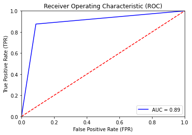

```python
#---find the area under the curve---

roc_auc = auc(fpr, tpr)

import matplotlib.pyplot as plt
plt.plot(fpr, tpr, 'b', label = 'AUC = %0.2f' % roc_auc)
plt.plot([0, 1], [0, 1],'r--')
plt.xlim([0, 1])
plt.ylim([0, 1])
plt.ylabel('True Positive Rate (TPR)')
plt.xlabel('False Positive Rate (FPR)')
plt.title('Receiver Operating Characteristic (ROC)')
plt.legend(loc = 'lower right')
plt.show()
```

## Plotting Decision Boundary

```python
## install mlxtend library

# !pip install mlxtend
```

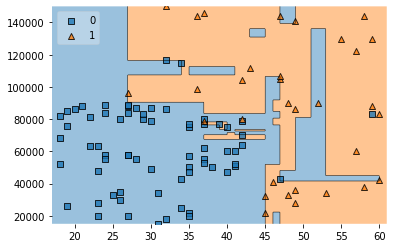

```python
import matplotlib.pyplot as plt
from mlxtend.plotting import plot_decision_regions
# import matplotlib.gridspec as gridspec
%matplotlib inline

plot_decision_regions(X=X_test, y=y_test, clf=classifier, legend=2)
```

```python
# !pip install pydotplus
```

If it doesn't work, open anaconda prompt and use the following commands one-by-one:

- conda install pydotplus
- conda install python-graphviz

Restart your Jupyter Notebook and Run all cells.

```python
from pydotplus import graph_from_dot_data
from sklearn.tree import export_graphviz

dot_data = export_graphviz(classifier,filled=True,rounded=True)
graph = graph_from_dot_data(dot_data)
graph.write_png('decision_tree.png')
```

```
True
```

### Optimizing the Decision Tree Classifier

`criterion`: optional (default=”gini”) or Choose attribute selection measure: This parameter allows us to use the different-different attribute selection measure. Supported criteria are **“gini” for the Gini index and “entropy” for the information gain**.

`max_depth`: int or None, optional (default=None) or Maximum Depth of a Tree: The maximum depth of the tree. If None, then nodes are expanded until all the leaves contain less than min_samples_split samples. The higher value of maximum depth causes overfitting, and a lower value causes underfitting (Source).

```python
#decison tree using Information Gain

from sklearn.tree import DecisionTreeClassifier

classifier2 = DecisionTreeClassifier(criterion = 'entropy', random_state = 0)
classifier2.fit(X_train, y_train)
```

```
DecisionTreeClassifier(criterion='entropy', random_state=0)
```

```python
# predictions

y_pred = classifier2.predict(X_test)

# y_pred
```

```
[[62  6]
 [ 3 29]]
```

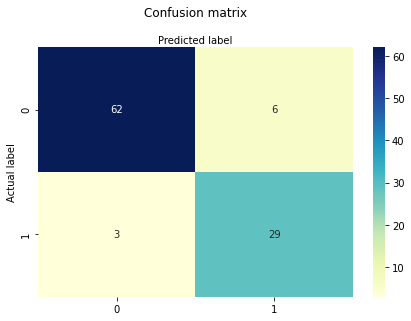

```python
# Confusion  Matrix

cm = confusion_matrix(y_test, y_pred)
print(cm)

class_names=[0,1] # name  of classes

fig, ax = plt.subplots()
tick_marks = np.arange(len(class_names))
plt.xticks(tick_marks, class_names)
plt.yticks(tick_marks, class_names)

# create heatmap
sns.heatmap(pd.DataFrame(cm), annot=True, cmap="YlGnBu" ,fmt='g')
ax.xaxis.set_label_position("top")
plt.tight_layout()
plt.title('Confusion matrix', y=1.1)
plt.ylabel('Actual label')
plt.xlabel('Predicted label')
```

```python
# View summary of common classification metrics

print("---Metrices---")
print(metrics.classification_report(y_true = y_test, y_pred = y_pred))
```

```
---Metrices---
              precision    recall  f1-score   support

           0       0.95      0.91      0.93        68
           1       0.83      0.91      0.87        32

    accuracy                           0.91       100
   macro avg       0.89      0.91      0.90       100
weighted avg       0.91      0.91      0.91       100
```

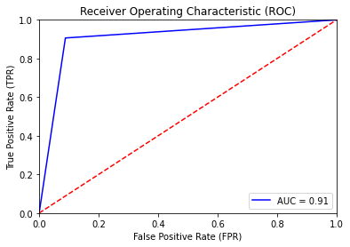

```python
# roc curve

#---find the predicted probabilities using the test set
probs = classifier2.predict_proba(X_test)
preds = probs[:,1]

#---find the FPR, TPR, and threshold---
fpr, tpr, threshold = roc_curve(y_test, preds)

#---find the area under the curve---

roc_auc = auc(fpr, tpr)

plt.plot(fpr, tpr, 'b', label = 'AUC = %0.2f' % roc_auc)
plt.plot([0, 1], [0, 1],'r--')
plt.xlim([0, 1])
plt.ylim([0, 1])
plt.ylabel('True Positive Rate (TPR)')
plt.xlabel('False Positive Rate (FPR)')
plt.title('Receiver Operating Characteristic (ROC)')
plt.legend(loc = 'lower right')
plt.show()
```

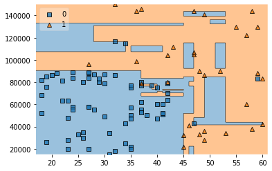

```python
# decison boundary

plot_decision_regions(X=X_test, y=y_test, clf=classifier2, legend=2)
```

```python
# saving decision tree as image


dot_data = export_graphviz(classifier2,filled=True,rounded=True)
graph = graph_from_dot_data(dot_data)
graph.write_png('decision_tree2.png')
```

```
True
```

#### Try some more parameter tuning such as setting `max_depth`